# PPOL670 | Introduction to Data Science | Week 10

Walkthrough using regression methods with `caret`

# Overview

In this notebook, we’ll apply the machine learning concepts covered in the supervised learning lecture on regression methods. Note that there are many libraries that can perform the methods that we reviewed in class, but we’ll focus here on using the `caret` package to perform these operations.

# Dependencies

```r
require(tidyverse)
require(caret) # for machine learning
require(recipes) # For preprocessing your data
require(rsample) # for train test splits
require(rattle) # For nice tree plots
require(yardstick) # for performance metrics

# For parallelization (to run the models across many cores) -- speeds up computation!
# install.packages("doMC")
doMC::registerDoMC()
```

# Data

For this exercise, let’s examine some historical data of bike sharing in London downloaded from Kaggle. The data contains information on rider usage given a common set of climate and time predictors.

Assume we work for the company that runs the ride sharing venture: our aim is to build a model that best predicts the number of riders (`cnt`) at any given moment in time so that we can distribute resources appropriately. Please see the Kaggle site for a description of the variables: https://www.kaggle.com/hmavrodiev/london-bike-sharing-dataset#london_merged.csv

```r
dat = read_csv("london_bike_sharing.csv")
glimpse(dat)
```

```
Rows: 17,414
Columns: 10
$ timestamp    <dttm> 2015-01-04 00:00:00, 2015-01-04 01:00:00, 2015-01-04 …
$ cnt          <dbl> 182, 138, 134, 72, 47, 46, 51, 75, 131, 301, 528, 727,…
$ t1           <dbl> 3.0, 3.0, 2.5, 2.0, 2.0, 2.0, 1.0, 1.0, 1.5, 2.0, 3.0,…
$ t2           <dbl> 2.0, 2.5, 2.5, 2.0, 0.0, 2.0, -1.0, -1.0, -1.0, -0.5, …
$ hum          <dbl> 93.0, 93.0, 96.5, 100.0, 93.0, 93.0, 100.0, 100.0, 96.…
$ wind_speed   <dbl> 6.0, 5.0, 0.0, 0.0, 6.5, 4.0, 7.0, 7.0, 8.0, 9.0, 12.0…
$ weather_code <dbl> 3, 1, 1, 1, 1, 1, 4, 4, 4, 3, 3, 3, 4, 3, 3, 3, 3, 3, …
$ is_holiday   <dbl> 0, 0, 0, 0, 0, 0, 0, 0, 0, 0, 0, 0, 0, 0, 0, 0, 0, 0, …
$ is_weekend   <dbl> 1, 1, 1, 1, 1, 1, 1, 1, 1, 1, 1, 1, 1, 1, 1, 1, 1, 1, …
$ season       <dbl> 3, 3, 3, 3, 3, 3, 3, 3, 3, 3, 3, 3, 3, 3, 3, 3, 3, 3, …
```

# Split the Sample: Training and test data

Before event looking at the data, let’s split the sample up into a training and test dataset. We’ll completely hold off on viewing the test data, so as not to bias our development of the learning model.

```r
set.seed(123)
splits = initial_split(dat,prop = .8)
train_data = training(splits) # Use 80% of the data as training data
test_data = testing(splits) # holdout 20% as test data

dim(train_data)
```

```
[1] 13932    10
```

```r
dim(test_data)
```

```
[1] 3482   10
```

# Examine the Data

```r
summary(train_data)
```

```
   timestamp                        cnt               t1
 Min.   :2015-01-04 00:00:00   Min.   :   0.0   Min.   :-1.50
 1st Qu.:2015-07-03 14:45:00   1st Qu.: 252.8   1st Qu.: 8.00
 Median :2016-01-02 10:30:00   Median : 840.0   Median :12.50
 Mean   :2016-01-03 02:55:35   Mean   :1136.1   Mean   :12.45
 3rd Qu.:2016-07-04 07:45:00   3rd Qu.:1657.0   3rd Qu.:16.00
 Max.   :2017-01-03 23:00:00   Max.   :7860.0   Max.   :34.00
       t2            hum          wind_speed     weather_code
 Min.   :-6.0   Min.   : 20.5   Min.   : 0.00   Min.   : 1.000
 1st Qu.: 6.0   1st Qu.: 63.0   1st Qu.:10.00   1st Qu.: 1.000
 Median :12.5   Median : 75.0   Median :15.00   Median : 2.000
 Mean   :11.5   Mean   : 72.5   Mean   :15.87   Mean   : 2.733
 3rd Qu.:16.0   3rd Qu.: 83.0   3rd Qu.:20.50   3rd Qu.: 3.000
 Max.   :34.0   Max.   :100.0   Max.   :56.50   Max.   :26.000
   is_holiday        is_weekend         season
 Min.   :0.00000   Min.   :0.0000   Min.   :0.000
 1st Qu.:0.00000   1st Qu.:0.0000   1st Qu.:0.000
 Median :0.00000   Median :0.0000   Median :1.000
 Mean   :0.02146   Mean   :0.2872   Mean   :1.495
 3rd Qu.:0.00000   3rd Qu.:1.0000   3rd Qu.:3.000
 Max.   :1.00000   Max.   :1.0000   Max.   :3.000
```

Let’s look at the temporal coverage: Looks like the data roughly covers a two year time span.

```r
dat %>%
  summarize(min_date = min(timestamp),
            max_date = max(timestamp))
```

| min_date | max_date |
| --- | --- |
| 2015-01-04 | 2017-01-03 23:00:00 |

Visualize the distribution for each variable.

First, let’s look at the numerical variables.

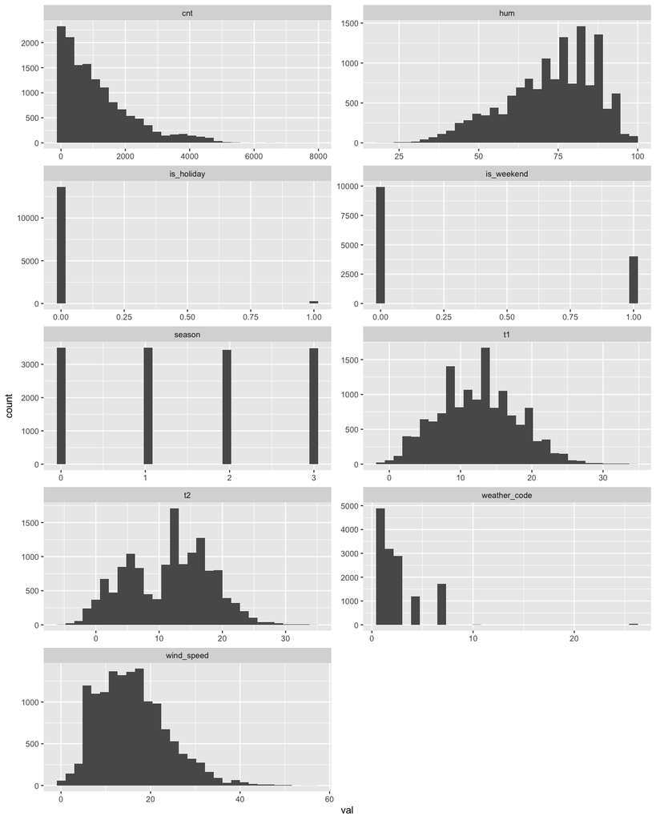

```r
train_data %>%
  select_if(is.numeric) %>%
  gather(var,val) %>% # equivalent to pivot_longer
  ggplot(aes(val,group=var)) +
  geom_histogram(bins = 30) +
  facet_wrap(~var,scales="free",ncol=2)
```

Most of the variables are continuous values. Some variables appear to be dummy (`is_weekend`) or ordered (`season`) variables. For the seasons, we may want to consider changing this variable to a dummy variable (where each season acts as a dummy variable) since the “order” in the seasons isn’t implied (i.e. winter isn’t necessarily worse than Fall, etc.).

Also, note that the weather code data is a bit of an enigma. There isn’t clear information online regarding what the code means, so we may want to drop it as we’re unsure about it.

It doesn’t appear that there is any missing data, so there is no need to impute any data.

```r
sum(is.na(train_data)) # any missingness??
```

```
[1] 0
```

Finally, note that the outcome variable is a count, so we may want to log transform it so that it’s less skewed.

# Pre-process the Data

What do we need to do?

- Seasons variable to dummies
- Scale all the variables so that they fall into a 0 to 1 range.
- No need to impute missing values. All the data is there.

```r
# First, turn the season variable into a categorical variable
clean_steps = function(.data){
  .data %>%
  mutate(season = as.factor(season)) %>%
  select(-timestamp,-weather_code)
}

# Generate our recipe to preprocess the data
rcp <-
  recipe(cnt~.,data = train_data %>% clean_steps) %>%
  step_dummy(all_nominal(),-cnt) %>%

  # log the dependent variable so it's more normal, offset the count by 1 for instances when cnt==0
  step_log(cnt,offset=1) %>%

  step_range(all_numeric(),-cnt) %>%  # Normalize scale
  prep()


# Apply the recipe to the training and test data
train_data2 <- bake(rcp,train_data %>% clean_steps)
test_data2 <- bake(rcp,test_data%>% clean_steps) # Need to transform the seasons data here as well.
```

Let’s examine the post-processed data.

```r
train_data2 %>% glimpse()
```

```
Rows: 13,932
Columns: 10
$ t1         <dbl> 0.12676056, 0.12676056, 0.11267606, 0.09859155, 0.098591…
$ t2         <dbl> 0.2000, 0.2125, 0.2125, 0.2000, 0.2000, 0.1250, 0.1250, …
$ hum        <dbl> 0.9119497, 0.9119497, 0.9559748, 1.0000000, 0.9119497, 1…
$ wind_speed <dbl> 0.10619469, 0.08849558, 0.00000000, 0.00000000, 0.070796…
$ is_holiday <dbl> 0, 0, 0, 0, 0, 0, 0, 0, 0, 0, 0, 0, 0, 0, 0, 0, 0, 0, 0,…
$ is_weekend <dbl> 1, 1, 1, 1, 1, 1, 1, 1, 1, 1, 1, 1, 1, 1, 1, 1, 1, 1, 1,…
$ cnt        <dbl> 5.209486, 4.934474, 4.905275, 4.290459, 3.850148, 3.9512…
$ season_X1  <dbl> 0, 0, 0, 0, 0, 0, 0, 0, 0, 0, 0, 0, 0, 0, 0, 0, 0, 0, 0,…
$ season_X2  <dbl> 0, 0, 0, 0, 0, 0, 0, 0, 0, 0, 0, 0, 0, 0, 0, 0, 0, 0, 0,…
$ season_X3  <dbl> 1, 1, 1, 1, 1, 1, 1, 1, 1, 1, 1, 1, 1, 1, 1, 1, 1, 1, 1,…
```

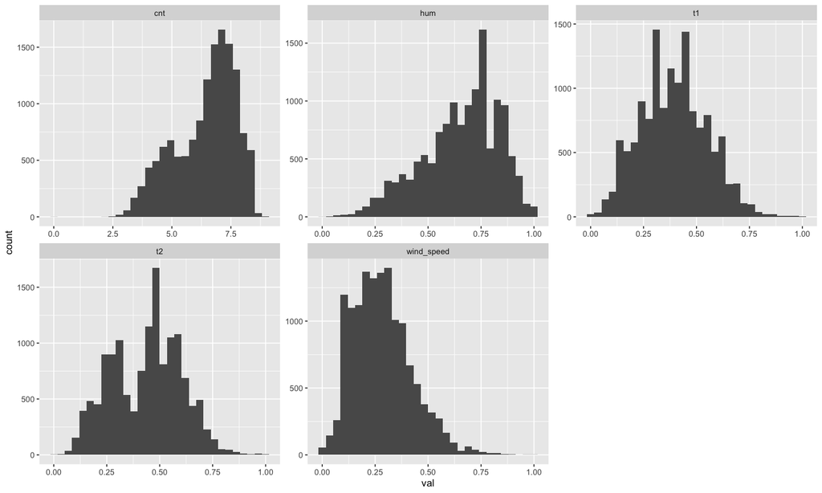

```r
train_data2 %>%
  select(cnt,hum,wind_speed,t1,t2) %>%
  gather(var,val) %>%
  ggplot(aes(val,group=var)) +
  geom_histogram(bins = 30) +
  facet_wrap(~var,scales="free",ncol=3)
```

# Cross-validation

When comparing different machine learning models, we want to make sure we’re making a fair and equal comparison. One way that random chance can sneak into our assessments of model fit is through cross-validation. We want to make sure that we’re cross-validating the data on the *exact same data partitions*.

`caret` makes this ease to do. Let’s use the k-fold cross-validation method with 10 folds in the data.

```r
set.seed(1988) # set a seed for replication purposes

folds <- createFolds(train_data2$cnt, k = 10) # Partition the data into 10 equal folds

sapply(folds,length)
```

```
Fold01 Fold02 Fold03 Fold04 Fold05 Fold06 Fold07 Fold08 Fold09 Fold10
  1393   1393   1393   1393   1394   1393   1393   1393   1394   1393
```

Now, let’s use the `trainControl()` function from `caret` to set up our validation conditions

```r
control_conditions <-
  trainControl(method='cv', # K-fold cross validation
               index = folds # The indices for our folds (so they are always the same)
  )
```

We’ll now use this same cross-validation object for everything that we do.

# Models

Let’s explore the different models that we covered in the lecture using the same package framework. As we saw last time in class, `caret` facilitates this task nicely.

## Linear Regression

```r
mod_lm <-
  train(cnt ~ .,          # Equation (outcome and everything else)
        data=train_data2, # Training data
        method = "lm",    # linear model
        metric = "RMSE",   # mean squared error
        trControl = control_conditions # Cross validation conditions
  )
```

Let’s look at the performance plots. What do we see?

```r
mod_lm
```

```
Linear Regression

13932 samples
    9 predictor

No pre-processing
Resampling: Cross-Validated (10 fold)
Summary of sample sizes: 1393, 1393, 1393, 1393, 1394, 1393, ...
Resampling results:

  RMSE      Rsquared   MAE
  1.086514  0.2836169  0.8490306

Tuning parameter 'intercept' was held constant at a value of TRUE
```

## K-Nearest Neighbors

> Remember: these algorithms are computationally demanding, so they can take a little time to run depending on the power of your machine

```r
mod_knn <-
  train(cnt ~ .,           # Equation (outcome and everything else)
        data=train_data2,  # Training data
        method = "knn",    # K-Nearest Neighbors Algorithm
        metric = "RMSE",   # mean squared error
        trControl = control_conditions # Cross validation conditions
  )
```

Let’s look at the performance plots. What do we see?

```r
mod_knn
```

```
k-Nearest Neighbors

13932 samples
    9 predictor

No pre-processing
Resampling: Cross-Validated (10 fold)
Summary of sample sizes: 1393, 1393, 1393, 1393, 1394, 1393, ...
Resampling results across tuning parameters:

  k  RMSE      Rsquared   MAE
  5  1.156543  0.2201065  0.8775010
  7  1.133500  0.2357252  0.8641692
  9  1.121732  0.2448883  0.8582290

RMSE was used to select the optimal model using the smallest value.
The final value used for the model was k = 9.
```

- `caret` has default settings that auto explore different tunning parameters for the model.
- We can easily plot these tuning features using the standard plot functions (these function have been over-ridden in R)

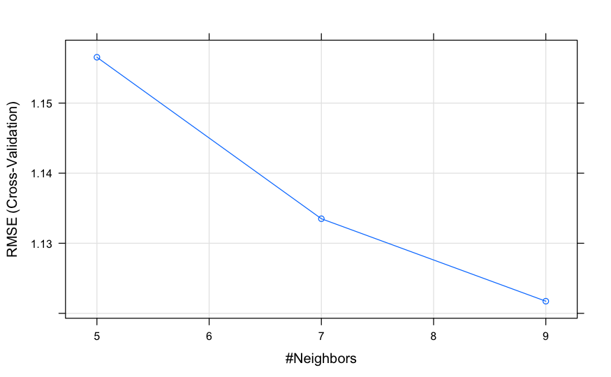

```r
plot(mod_knn)
```

```r
# Draw out the best model (the one with the best performance)
mod_knn$finalModel
```

```
9-nearest neighbor regression model
```

Now, let’s say we wanted to adjust the tunning parameters. We can explore different model tunings by using the `tuneGrid` argument.

```r
# Different values of the tuning parameter that I want to try.
knn_tune = expand.grid(k = c(1,3,10,50))

mod_knn <-
  train(cnt ~ .,           # Equation (outcome and everything else)
        data=train_data2,  # Training data
        method = "knn",    # K-Nearest Neighbors Algorithm
        metric = "RMSE",   # mean squared error
        trControl = control_conditions, # Cross validation conditions
        tuneGrid = knn_tune # Vary the tuning parameter K
  )
```

Look at performance: it doesn’t look that we get much of a boost when going all the way to K-Neighbors.

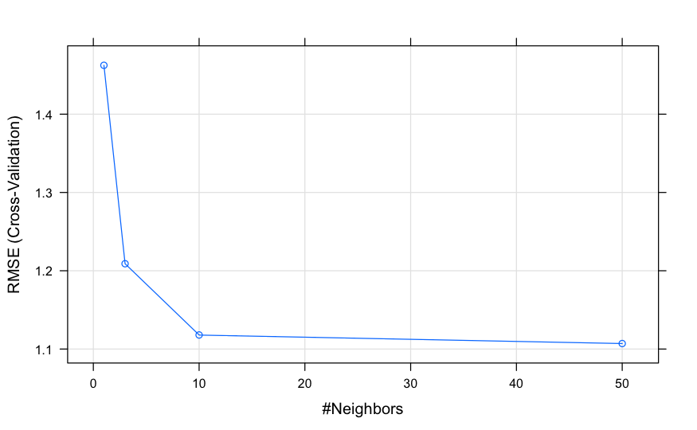

```r
plot(mod_knn)
```

## Decision Trees

```r
mod_cart <-
   train(cnt ~ .,            # Equation (outcome and everything else)
        data=train_data2,    # Training data
        method = "rpart",    # Regression tree
        metric = "RMSE",     # mean squared error
        trControl = control_conditions # Cross validation conditions
  )
```

```
There were missing values in resampled performance measures.
```

```r
mod_cart
```

```
CART

13932 samples
    9 predictor

No pre-processing
Resampling: Cross-Validated (10 fold)
Summary of sample sizes: 1393, 1393, 1393, 1393, 1394, 1393, ...
Resampling results across tuning parameters:

  cp          RMSE      Rsquared   MAE
  0.01485955  1.132224  0.2231094  0.8932458
  0.03063670  1.145529  0.2040795  0.9084821
  0.18437882  1.224750  0.1756298  0.9938378

RMSE was used to select the optimal model using the smallest value.
The final value used for the model was cp = 0.01485955.
```

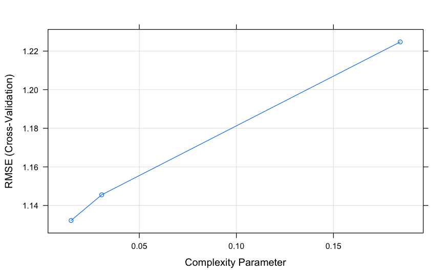

```r
plot(mod_cart)
```

Let’s visualize the tree we just grew. It looks like the humidity level is an important factor when predicting othe number of riders.

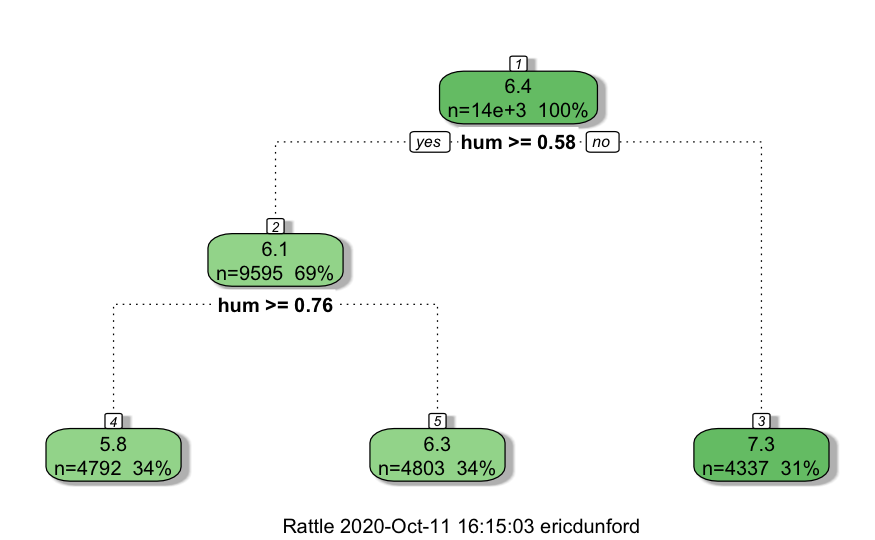

```r
# This tree goes really deep
fancyRpartPlot(mod_cart$finalModel)
```

We can actually print out the larger decision tree to look at it as a print out.

```r
print(mod_cart$finalModel)
```

```
n= 13932

node), split, n, deviance, yval
      * denotes terminal node

1) root 13932 22943.490 6.432077
  2) hum>=0.581761 9595 15936.980 6.061609
    4) hum>=0.7578616 4792  7853.797 5.790636 *
    5) hum< 0.7578616 4803  7380.268 6.331962 *
  3) hum< 0.581761 4337  2776.215 7.251685 *
```

Let’s free the CART to grow deeper.

```r
tune_cart <- expand.grid(cp = c(0.0010281)) # Complexity Parameter (how "deep" our trees should grow)
mod_cart2 <-
  train(cnt ~ ., # Equation (outcome and everything else)
        data=train_data2, # Training data
        method = "rpart", # Classification Tree
        metric = "RMSE",     # mean squared error
        tuneGrid = tune_cart, # Tuning parameters
        trControl = control_conditions
  )
```

Doesn’t doo a whole lot better on out of sample data.

```r
print(mod_cart2)
```

```
CART

13932 samples
    9 predictor

No pre-processing
Resampling: Cross-Validated (10 fold)
Summary of sample sizes: 1393, 1393, 1393, 1393, 1394, 1393, ...
Resampling results:

  RMSE      Rsquared   MAE
  1.183767  0.2028586  0.9005489

Tuning parameter 'cp' was held constant at a value of 0.0010281
```

Let’s look at the tree itself: much deeper!

```r
print(mod_cart2$finalModel)
```

```
n= 13932

node), split, n, deviance, yval
      * denotes terminal node

  1) root 13932 22943.49000 6.432077
    2) hum>=0.581761 9595 15936.98000 6.061609
      4) hum>=0.7578616 4792  7853.79700 5.790636
        8) t1< 0.2605634 1448  2597.67200 5.436264
         16) t1< 0.07746479 121   252.09270 4.926297 *
         17) t1>=0.07746479 1327  2311.24200 5.482765
           34) season_X3< 0.5 567   961.29990 5.246741 *
           35) season_X3>=0.5 760  1294.79100 5.658851 *
        9) t1>=0.2605634 3344  4995.54700 5.944084
         18) hum>=0.827044 1763  2698.72400 5.825637
           36) hum>=0.9213836 426   715.51500 5.624051 *
           37) hum< 0.9213836 1337  1960.38100 5.889867
             74) t2< 0.55625 1215  1791.01900 5.846821
              148) season_X3< 0.5 876  1310.68500 5.760265
                296) season_X2< 0.5 382   495.01600 5.521033 *
                297) season_X2>=0.5 494   776.90090 5.945258 *
              149) season_X3>=0.5 339   456.81180 6.070490
                298) wind_speed>=0.2743363 155   215.12410 5.741844 *
                299) wind_speed< 0.2743363 184   210.84380 6.347338 *
             75) t2>=0.55625 122   144.68960 6.318561 *
         19) hum< 0.827044 1581  2244.50700 6.076167
           38) t1< 0.4014085 741  1101.11800 5.941280 *
           39) t1>=0.4014085 840  1118.01300 6.195157
             78) season_X1>=0.5 377   476.53400 5.940694
              156) t1< 0.471831 104   109.92070 5.448241 *
              157) t1>=0.471831 273   331.78420 6.128295 *
             79) season_X1< 0.5 463   597.19050 6.402355 *
      5) hum< 0.7578616 4803  7380.26800 6.331962
       10) t2< 0.43125 2115  3563.82200 6.076456
         20) hum>=0.6823899 1059  1876.21200 5.886286
           40) t2< 0.20625 280   552.97330 5.632387 *
           41) t2>=0.20625 779  1298.70100 5.977546 *
         21) hum< 0.6823899 1056  1610.90400 6.267166
           42) season_X1>=0.5 18    23.61613 5.115742 *
           43) season_X1< 0.5 1038  1563.01000 6.287133
```

[output cut: 19 more lines]

```
    3) hum< 0.581761 4337  2776.21500 7.251685
      6) t1< 0.556338 2821  2045.30300 7.046150
       12) hum>=0.4685535 1576  1499.99300 6.835304
         24) season_X2< 0.5 1206  1232.08800 6.737609
           48) wind_speed< 0.2876106 524   648.99110 6.551511 *
           49) wind_speed>=0.2876106 682   551.00610 6.880593
             98) t2< 0.18125 63    52.57687 6.209068 *
             99) t2>=0.18125 619   467.12820 6.948939 *
         25) season_X2>=0.5 370   218.87730 7.153737 *
       13) hum< 0.4685535 1245   386.55590 7.313053
         26) t1< 0.3873239 489   153.89480 7.100934 *
         27) t1>=0.3873239 756   196.42720 7.450257 *
      7) t1>=0.556338 1516   389.98270 7.634149
       14) hum>=0.3490566 960   273.05850 7.518575 *
       15) hum< 0.3490566 556    81.96064 7.833701 *
```

## Random Forest

```r
mod_rf <-
  train(cnt ~ ., # Equation (outcome and everything else)
        data=train_data2, # Training data
        method = "ranger", # random forest (ranger is much faster than rf)
        metric = "RMSE",     # mean squared error
        trControl = control_conditions
  )
```

There are three tunning parameters in this model:

```r
mod_rf
```

```
Random Forest

13932 samples
    9 predictor

No pre-processing
Resampling: Cross-Validated (10 fold)
Summary of sample sizes: 1393, 1393, 1393, 1393, 1394, 1393, ...
Resampling results across tuning parameters:

  mtry  splitrule   RMSE      Rsquared   MAE
  2     variance    1.081815  0.2902953  0.8334833
  2     extratrees  1.091484  0.2931923  0.8514838
  5     variance    1.113119  0.2601100  0.8485382
  5     extratrees  1.093944  0.2777063  0.8331818
  9     variance    1.122639  0.2519127  0.8557224
  9     extratrees  1.105312  0.2678914  0.8398917

Tuning parameter 'min.node.size' was held constant at a value of 5
RMSE was used to select the optimal model using the smallest value.
The final values used for the model were mtry = 2, splitrule = variance
 and min.node.size = 5.
```

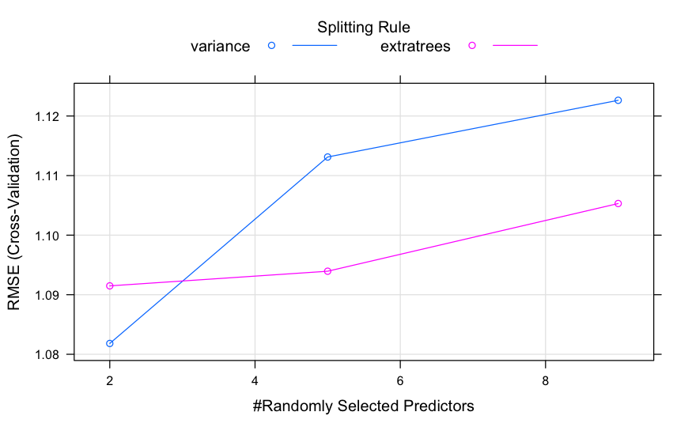

```r
plot(mod_rf)
```

```r
mod_rf$bestTune
```

|  | mtry | splitrule | min.node.size |
| --- | --- | --- | --- |
| 1 | 2 | variance | 5 |

# Model Comparison

How did the different methods perform? Which one did the best?

```r
# Organize all model imputs as a list.
mod_list <-
  list(
    lm = mod_lm,
    knn = mod_knn,
    cart = mod_cart,
    cart_deep = mod_cart2,
    rf = mod_rf
  )

# Resamples allows us to compare model output
resamples(mod_list)
```

```
Call:
resamples.default(x = mod_list)

Models: lm, knn, cart, cart_deep, rf
Number of resamples: 10
Performance metrics: MAE, RMSE, Rsquared
Time estimates for: everything, final model fit
```

Examine the error across each of the models.

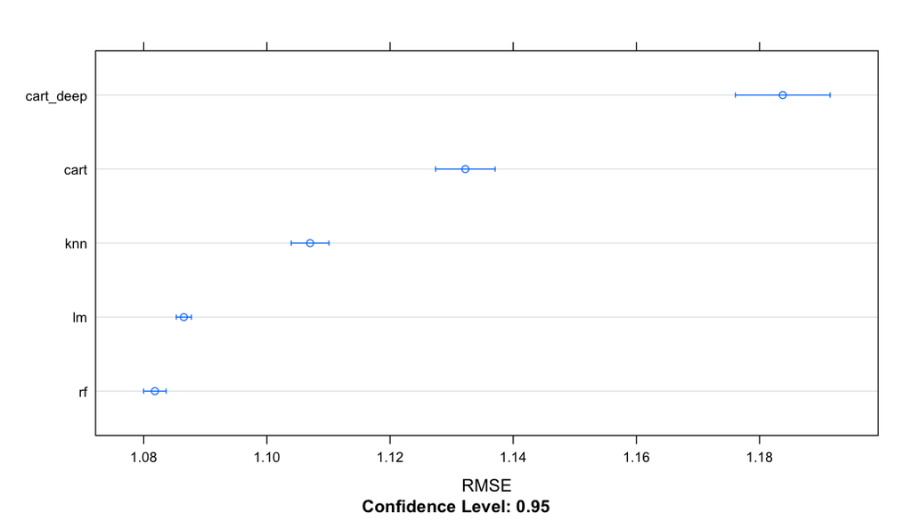

```r
dotplot(resamples(mod_list),metric = "RMSE")
```

Examine the fit across each of the models.

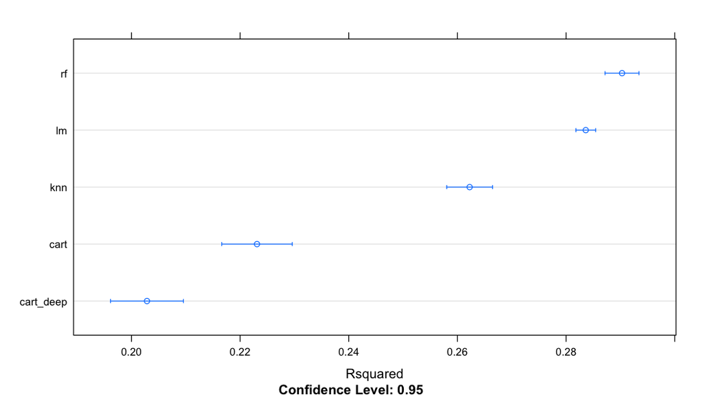

```r
dotplot(resamples(mod_list),metric = "Rsquared")
```

# Test the Predictive Accuracy of the Best Model

Of the models we ran, it looks like the Random Forest model did the best. Let’s now see how well it does on predicting the test data.

```r
pred <- predict(mod_rf,newdata = test_data2)
mse = sum((test_data2$cnt-pred)^2)/nrow(test_data2)
rmse_score = sqrt(mse)
rmse_score
```

```
[1] 1.024161
```

We can also use the `yardstick` package to calculate performance metrics.

```r
# Generate a prediction on our test data.
pred <- predict(mod_rf,newdata = test_data2)


# Organize as a data frame
performance = tibble(truth=test_data2$cnt,estimate = pred)

# Calculate performance metrics
bind_rows(
  performance %>% rmse(truth,estimate), # Root Mean Squared Error
  performance %>% rsq(truth,estimate) # R Squared
)
```

| .metric | .estimator | .estimate |
| --- | --- | --- |
| rmse | standard | 1.0241611 |
| rsq | standard | 0.3666233 |